# factorMerger: set of tools to support results from post hoc testing

Agnieszka Sitko

2017-05-03

# Introduction

The aim of `factorMerger` is to provide set of tools to support results from post hoc comparisons. Post hoc testing is an analysis performed after running *ANOVA* to examine differences between group means (of some response numeric variable) for each pair of groups (groups are defined by a factor variable).

This project arose from the need to create a method of post hoc testing which gives the hierarchical interpretation of relations between groups means. Thereby, for a given significance level we may divide groups into nonoverlapping clusters.

# Algorithm inputs

In the current version the **factorMerger** package supports parametric models:

- one-dimensional Gaussian (with the argument `family = "gaussian"`),
- multi dimensional Gaussian (with the argument `family = "gaussian"`),
- binomial (with the argument `family = "binomial"`),
- survival (with the argument `family = "survival"`).

Set of hypotheses that are tested during merging may be either comprehensive or limited. This gives two possibilities:

- *all-to-all* (with the argument `successive = FALSE`),
- *successive* (with the argument `successive = TRUE`).

The version *all-to-all* considers all possible pairs of factor levels. In the *successive* approach factor levels are preliminarily sorted and then only consecutive groups are tested for means equality.

The **factorMerger** package also implements two strategies of a single iteration of the algorithm. They use one of the following:

- *Likelihood Ratio Test* (with the argument `method = "LRT"`),
- *agglomerative clustering with constant distance matrix* (based on the *DMR4glm* algorithm Prochenka 2016, with the argument `method = "hclust"`).

# Generating samples

To visualize functionalities of `factorMerger` we use samples for which response variable is generated from one of the distributions listed above and corresponding factor variable is sampled uniformly from a finite set of a size $k$.

To do so, we may use function `generateSample` or `generateMultivariateSample`.

```r
library(factorMerger)
library(knitr)
library(dplyr)
randSample <- generateMultivariateSample(N = 100, k = 10, d = 3)
```

# Merging factors

`mergeFactors` is a function that performs hierarchical post hoc testing. As arguments it takes:

- matrix/data.frame/vector with numeric response,
- factor vector defining groups.

By default (with argument `abbreviate = TRUE`) factor levels are abbreviated and surrounded with brackets.

## Multi-dimensional Gaussian model

### Computations

```r
fmAll <- mergeFactors(randSample$response, randSample$factor)
```

`mergeFactors` outputs with information about the ‘merging history’.

```r
mergingHistory(fmAll, showStats = TRUE) %>%
    kable()
```

| groupA | groupB | model | GIC | pvalVsFull | pvalVsPrevious |
| --- | --- | --- | --- | --- | --- |
|  |  | -583.0985 | 1186.197 | 1.0000 | 1.0000 |
| (F) | (E) | -583.1770 | 1184.354 | 0.9868 | 0.9868 |
| (A) | (B) | -583.5992 | 1183.198 | 0.9891 | 0.8600 |
| (D) | (C) | -584.7755 | 1183.551 | 0.9627 | 0.5461 |
| (G) | (I) | -585.9748 | 1183.949 | 0.9489 | 0.5330 |
| (H) | (A)(B) | -588.4350 | 1186.870 | 0.8344 | 0.2078 |
| (F)(E) | (J) | -591.6986 | 1191.397 | 0.6111 | 0.1067 |
| (H)(A)(B) | (D)(C) | -597.1654 | 1200.331 | 0.2354 | 0.0159 |
| (H)(A)(B)(D)(C) | (F)(E)(J) | -605.6794 | 1215.359 | 0.0160 | 0.0010 |
| (H)(A)(B)(D)(C)(F)(E)(J) | (G)(I) | -619.1469 | 1240.294 | 0.0001 | 0.0000 |

Each row of the above frame describes one step of the merging algorithm. First two columns specify which groups were merged in the iteration, columns *model* and *GIC* gather loglikelihood and Generalized Information Criterion for the model after merging. Last two columns are p-values for the *Likelihood Ratio Test* – against the full model (*pvalVsFull*) and against the previous one (*pvalVsPrevious*).

If we set `successive = TRUE` then at the beginning one dimensional response is fitted using `isoMDS{MASS}`. Next, in each step only groups whose means are closed are compared.

```r
fm <- mergeFactors(randSample$response, randSample$factor,
                   successive = TRUE,
                   method = "hclust")

mergingHistory(fm, showStats = TRUE) %>%
    kable()
```

| groupA | groupB | model | GIC | pvalVsFull | pvalVsPrevious |
| --- | --- | --- | --- | --- | --- |
|  |  | -583.0985 | 1186.197 | 1.0000 | 1.0000 |
| (F) | (E) | -583.1770 | 1184.354 | 0.9868 | 0.9868 |
| (A) | (B) | -583.5992 | 1183.198 | 0.9891 | 0.8600 |
| (D) | (C) | -584.7755 | 1183.551 | 0.9627 | 0.5461 |
| (G) | (I) | -585.9748 | 1183.949 | 0.9489 | 0.5330 |
| (A)(B) | (F)(E) | -588.9627 | 1187.926 | 0.7767 | 0.1370 |
| (H) | (D)(C) | -591.5613 | 1191.123 | 0.6354 | 0.1824 |
| (A)(B)(F)(E) | (J) | -596.7372 | 1199.475 | 0.2691 | 0.0205 |
| (H)(D)(C) | (A)(B)(F)(E)(J) | -605.6794 | 1215.359 | 0.0160 | 0.0007 |
| (H)(D)(C)(A)(B)(F)(E)(J) | (G)(I) | -619.1469 | 1240.294 | 0.0001 | 0.0000 |

### Final clusters

Algorithms implemented in the **factorMerger** package enable to create unequivocal partition of a factor. Below we present how to extract the partition from the `mergeFactor` output.

- predict new labels for observations

```r
cutTree(fm)
```

```
#>   [1] (C)    (J)    (F)(E) (H)    (H)    (H)    (F)(E) (J)    (F)(E) (J)
#>  [11] (C)    (G)    (A)(B) (F)(E) (G)    (A)(B) (F)(E) (F)(E) (I)    (D)
#>  [21] (D)    (C)    (G)    (F)(E) (I)    (J)    (J)    (C)    (A)(B) (C)
#>  [31] (F)(E) (H)    (I)    (F)(E) (F)(E) (F)(E) (C)    (F)(E) (A)(B) (J)
#>  [41] (F)(E) (G)    (A)(B) (A)(B) (F)(E) (F)(E) (F)(E) (G)    (F)(E) (A)(B)
#>  [51] (D)    (J)    (I)    (J)    (J)    (F)(E) (H)    (D)    (C)    (C)
#>  [61] (H)    (F)(E) (A)(B) (J)    (F)(E) (A)(B) (G)    (J)    (A)(B) (C)
#>  [71] (I)    (J)    (A)(B) (I)    (A)(B) (I)    (F)(E) (I)    (F)(E) (H)
#>  [81] (G)    (I)    (H)    (J)    (I)    (A)(B) (G)    (H)    (H)    (F)(E)
#>  [91] (A)(B) (J)    (F)(E) (A)(B) (G)    (F)(E) (J)    (A)(B) (J)    (H)
#> Levels: (H) (D) (C) (A)(B) (F)(E) (J) (G) (I)
```

By default, `cutTree` returns a factor split for the optimal GIC (with penalty = 2) model. However, we can specify different metrics (`stat = c("loglikelihood", "p-value", "GIC"`) we would like to use in cutting. If `loglikelihood` or `p-value` is chosen an exact threshold must be given as a `value` parameter. Then `cutTree` returns factor for the smallest model whose statistic is higher than the threshold. If we choose `GIC` then `value` is interpreted as GIC penalty.

```r
mH <- mergingHistory(fm, T)
thres <- mH$model[nrow(mH) / 2]
cutTree(fm, stat = "loglikelihood", value = thres)
```

```
#>   [1] (D)(C) (J)    (F)(E) (H)    (H)    (H)    (F)(E) (J)    (F)(E) (J)
#>  [11] (D)(C) (G)(I) (A)(B) (F)(E) (G)(I) (A)(B) (F)(E) (F)(E) (G)(I) (D)(C)
#>  [21] (D)(C) (D)(C) (G)(I) (F)(E) (G)(I) (J)    (J)    (D)(C) (A)(B) (D)(C)
#>  [31] (F)(E) (H)    (G)(I) (F)(E) (F)(E) (F)(E) (D)(C) (F)(E) (A)(B) (J)
#>  [41] (F)(E) (G)(I) (A)(B) (A)(B) (F)(E) (F)(E) (F)(E) (G)(I) (F)(E) (A)(B)
#>  [51] (D)(C) (J)    (G)(I) (J)    (J)    (F)(E) (H)    (D)(C) (D)(C) (D)(C)
#>  [61] (H)    (F)(E) (A)(B) (J)    (F)(E) (A)(B) (G)(I) (J)    (A)(B) (D)(C)
#>  [71] (G)(I) (J)    (A)(B) (G)(I) (A)(B) (G)(I) (F)(E) (G)(I) (F)(E) (H)
#>  [81] (G)(I) (G)(I) (H)    (J)    (G)(I) (A)(B) (G)(I) (H)    (H)    (F)(E)
#>  [91] (A)(B) (J)    (F)(E) (A)(B) (G)(I) (F)(E) (J)    (A)(B) (J)    (H)
#> Levels: (H) (D)(C) (A)(B) (F)(E) (J) (G)(I)
```

In this example data partition is created for the last model from the merging path whose loglikelihood is greater than -585.9748.

- get final clusters and clusters dictionary

```r
getOptimalPartition(fm)
```

```
#> [1] "(H)"    "(D)"    "(C)"    "(A)(B)" "(F)(E)" "(J)"    "(G)"    "(I)"
```

Function `getOptimalPartition` returns a vector with the final cluster names from the factorMerger object.

```r
getOptimalPartitionDf(fm)
```

```
#>    orig   pred
#> 1   (C)    (C)
#> 2   (J)    (J)
#> 3   (F) (F)(E)
#> 4   (H)    (H)
#> 7   (E) (F)(E)
#> 12  (G)    (G)
#> 13  (B) (A)(B)
#> 16  (A) (A)(B)
#> 19  (I)    (I)
#> 20  (D)    (D)
```

Function `getOptimalPartitionDf` returns a dictionary in a data frame format. Each row gives an original label of a factor level and its new (cluster) label.

Similarly to `cutTree`, functions `getOptimalPartition` and `getOptimalPartitionDf` take arguments `stat` and `threshold`.

### Visualizations

We may plot results using function `plot`.

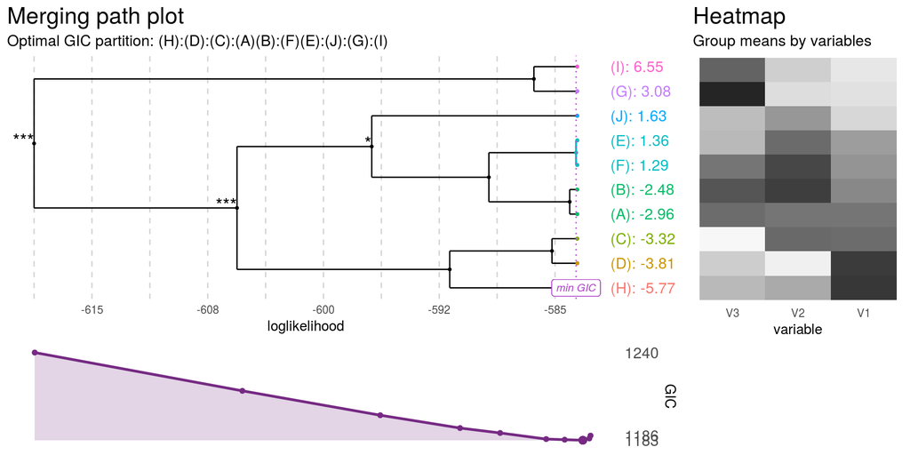

```r
plot(fm, panel = "all", nodesSpacing = "equidistant", color = "cluster")
```

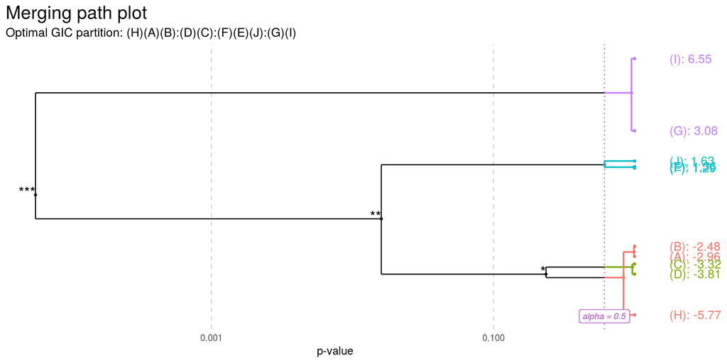

```r
plot(fmAll, panel = "merging", show = "p-value",
     nodesSpacing = "effects", color = "cluster",
     clusterSplit = list(stat = "p-value", alpha = 0.5),
     alpha = 0.5)
```

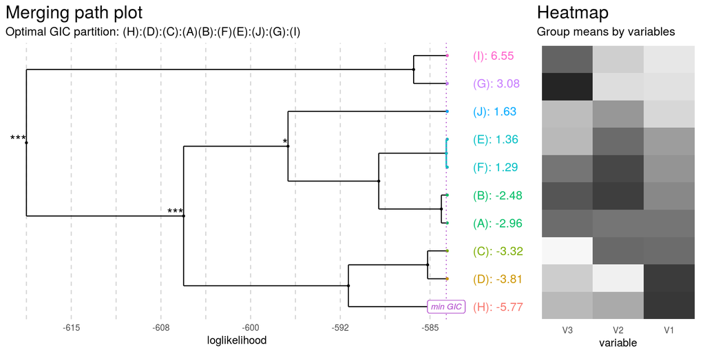

```r
plot(fm, color = "cluster", panel = "response")
```

The heatmap on the right shows means of all variables taken into analysis by groups.

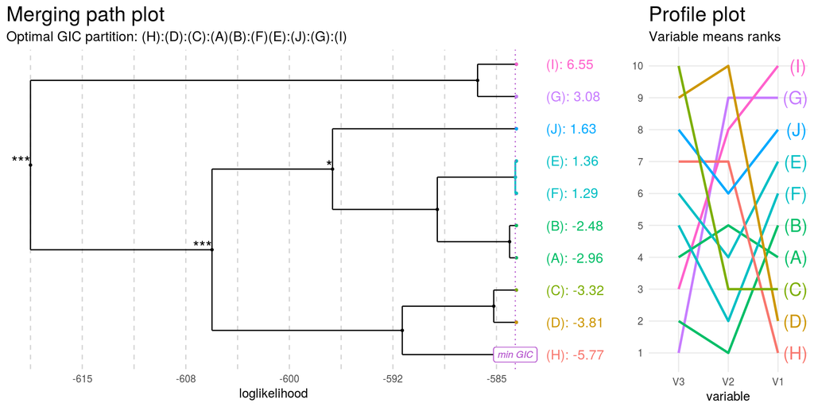

```r
plot(fm, color = "cluster", panel = "response", summary = "profile")
```

In the above plots colours are connected with the group. The plot on the right shows means rankings for all variables included in the algorithm.

It is also possible to plot *GIC* together with the merging path plot.

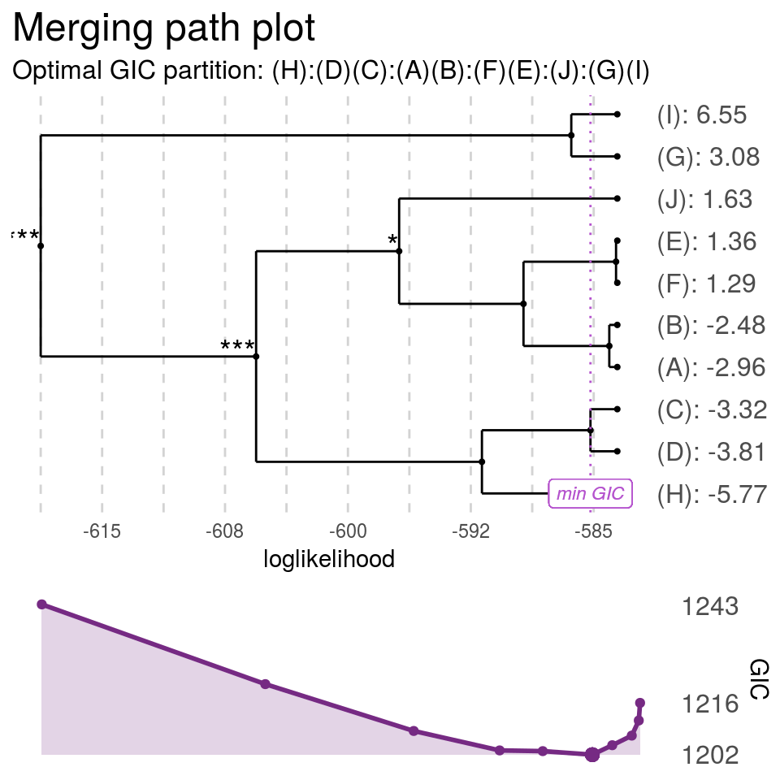

```r
plot(fm, panel = "GIC", penalty = 5,
     clusterSplit = list(stat = "GIC", value = 5))
```

Model with the lowest GIC is marked.

## One-dimensional Gaussian model

```r
oneDimRandSample <- generateSample(1000, 10)
```

```r
oneDimFm <- mergeFactors(oneDimRandSample$response, oneDimRandSample$factor,
                         method = "hclust")
mergingHistory(oneDimFm, showStats = TRUE) %>%
    kable()
```

| groupA | groupB | model | GIC | pvalVsFull | pvalVsPrevious |
| --- | --- | --- | --- | --- | --- |
|  |  | -3219.290 | 6458.581 | 1.0000 | 1.0000 |
| (B) | (E) | -3219.292 | 6456.583 | 0.9592 | 0.9592 |
| (B)(E) | (G) | -3219.301 | 6454.602 | 0.9897 | 0.8928 |
| (C) | (F) | -3219.312 | 6452.624 | 0.9977 | 0.8826 |
| (J) | (I) | -3219.470 | 6450.941 | 0.9859 | 0.5748 |
| (A) | (B)(E)(G) | -3219.865 | 6449.729 | 0.9507 | 0.3763 |
| (D) | (H) | -3221.041 | 6450.083 | 0.7474 | 0.1260 |
| (A)(B)(E)(G) | (C)(F) | -3222.905 | 6451.811 | 0.4108 | 0.0540 |
| (D)(H) | (J)(I) | -3231.854 | 6467.708 | 0.0016 | 0.0000 |
| (A)(B)(E)(G)(C)(F) | (D)(H)(J)(I) | -3296.211 | 6594.422 | 0.0000 | 0.0000 |

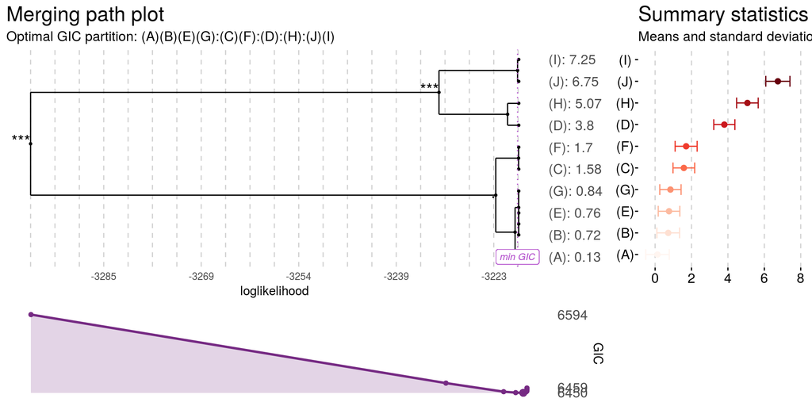

```r
plot(oneDimFm, responsePalette = "Reds")
```

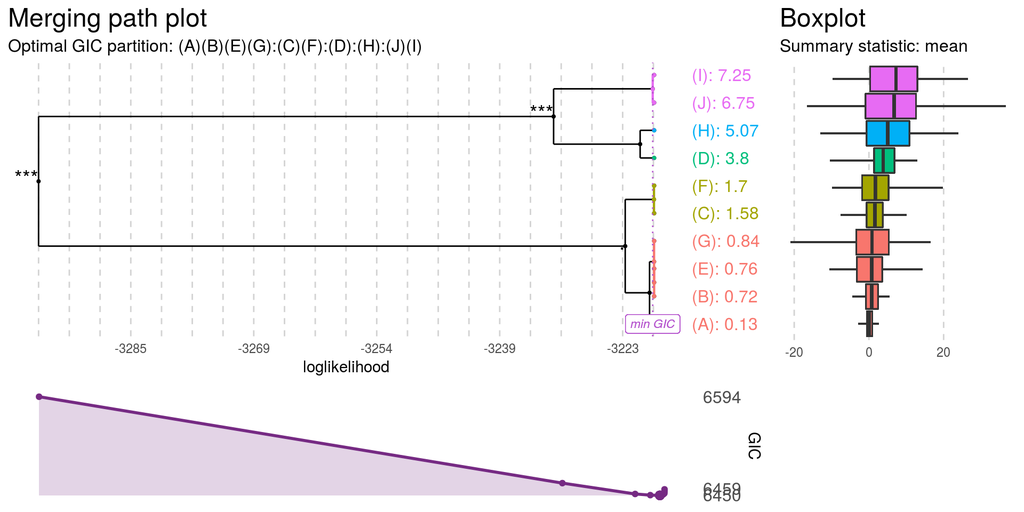

```r
plot(oneDimFm, summary = "boxplot", color = "cluster")
```

## Binomial model

If `family = "binomial"` response must have to values: `0` and `1` (`1` is interpreted as success).

```r
binomRandSample <- generateSample(1000, 10, distr = "binomial")
table(binomRandSample$response, binomRandSample$factor) %>%
    kable()
```

|  | I | F | A | G | H | J | E | B | C | D |
| --- | --- | --- | --- | --- | --- | --- | --- | --- | --- | --- |
| 0 | 84 | 66 | 61 | 55 | 52 | 52 | 51 | 40 | 17 | 8 |
| 1 | 21 | 29 | 37 | 47 | 46 | 54 | 55 | 69 | 68 | 88 |

```r
binomFm <- mergeFactors(binomRandSample$response,
                        binomRandSample$factor,
                        family = "binomial",
                        successive = TRUE)
mergingHistory(binomFm, showStats = TRUE) %>%
    kable()
```

| groupA | groupB | model | GIC | pvalVsFull | pvalVsPrevious |
| --- | --- | --- | --- | --- | --- |
|  |  | -602.6546 | 1225.309 | 1.0000 | 1.0000 |
| (G) | (H) | -602.6620 | 1223.324 | 0.9029 | 0.9029 |
| (J) | (E) | -602.6715 | 1221.343 | 0.9833 | 0.8907 |
| (G)(H) | (J)(E) | -603.1691 | 1220.338 | 0.7942 | 0.3185 |
| (F) | (A) | -603.7303 | 1219.461 | 0.7079 | 0.2894 |
| (C) | (D) | -606.3384 | 1222.677 | 0.1947 | 0.0224 |
| (I) | (F)(A) | -609.7837 | 1227.567 | 0.0269 | 0.0087 |
| (G)(H)(J)(E) | (B) | -613.3427 | 1232.685 | 0.0033 | 0.0076 |
| (I)(F)(A) | (G)(H)(J)(E)(B) | -633.8721 | 1271.744 | 0.0000 | 0.0000 |
| (I)(F)(A)(G)(H)(J)(E)(B) | (C)(D) | -692.7551 | 1387.510 | 0.0000 | 0.0000 |

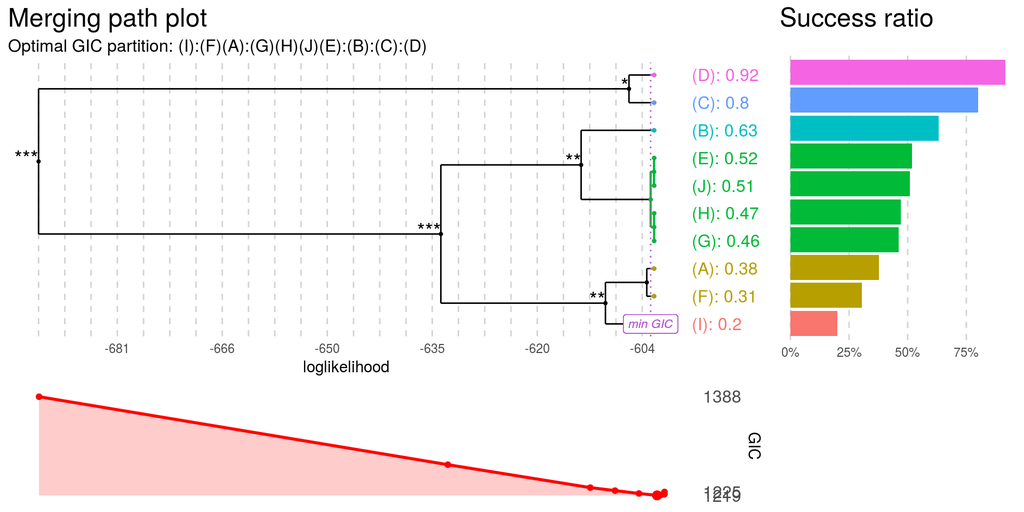

```r
plot(binomFm, color = "cluster", GICcolor = "red")
```

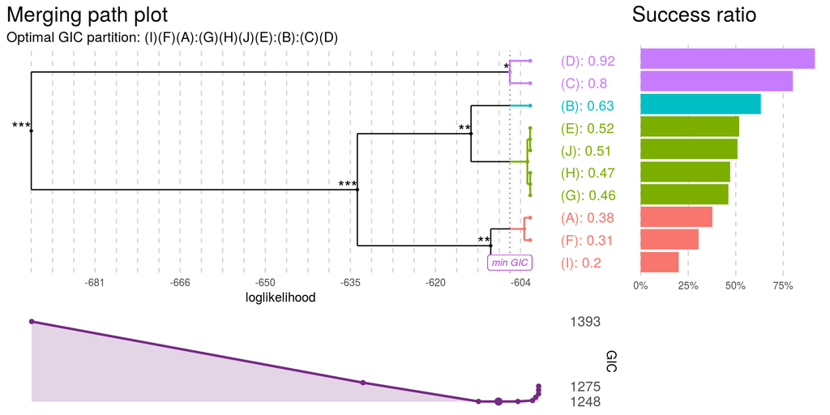

```r
plot(binomFm, color = "cluster",
     clusterSplit = list(stat = "GIC", penalty = 7), penalty = 7)
```

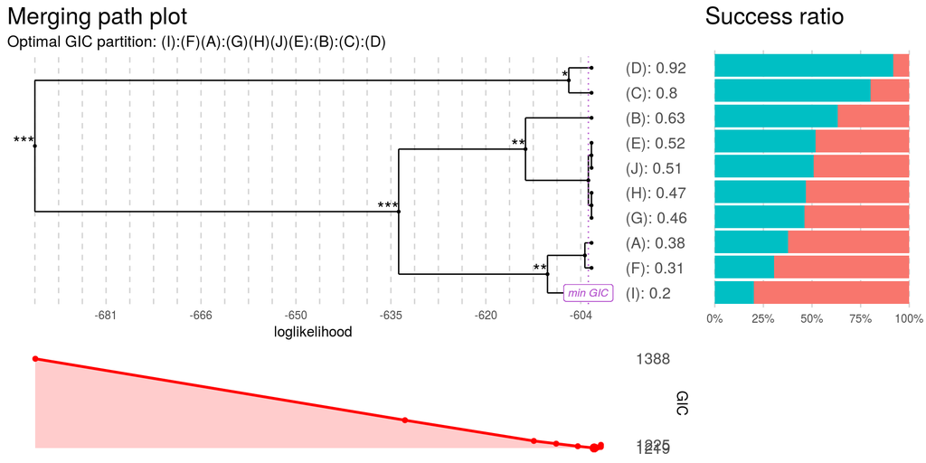

```r
plot(binomFm, GICcolor = "red")
```

## Survival model

If `family = "survival"` response must be of a class `Surv`.

```r
library(survival)
data(veteran)
survResponse <- Surv(time = veteran$time,
                 event = veteran$status)
survivalFm <- mergeFactors(response = survResponse,
                   factor = veteran$celltype,
                   family = "survival")
```

```r
mergingHistory(survivalFm, showStats = TRUE) %>%
    kable()
```

| groupA | groupB | model | GIC | pvalVsFull | pvalVsPrevious |
| --- | --- | --- | --- | --- | --- |
|  |  | -493.0247 | 994.0495 | 1.0000 | 1.0000 |
| (smll) | (aden) | -493.1951 | 992.3902 | 0.5594 | 0.5594 |
| (sqms) | (larg) | -493.5304 | 991.0609 | 0.6031 | 0.4128 |
| (sqms)(larg) | (smll)(aden) | -505.4491 | 1012.8981 | 0.0000 | 0.0000 |

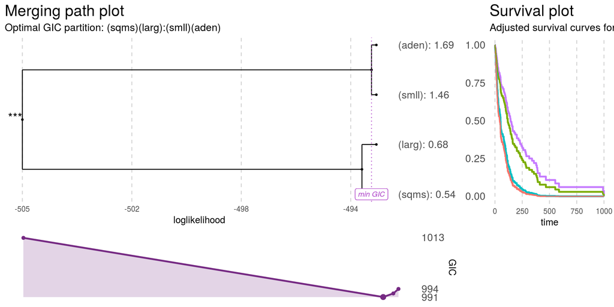

```r
plot(survivalFm)
```

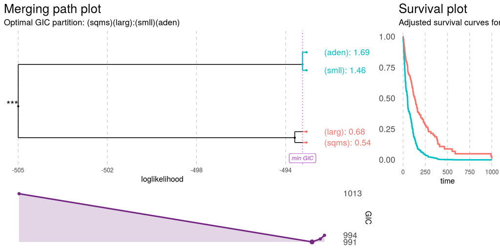

```r
plot(survivalFm, nodesSpacing = "effects", color = "cluster")
```

# Bibliography

Prochenka, Agnieszka. 2016. “Delete or Merge Regressors algorithm.” In *Polska Akadenia Nauk*, 37, 44–91.